# Assignment_7_ARIMA

Ritik Kumar

2024-11-22

## Importing the dataset

```r
library(forecast)
```

```r
library(ggplot2)
library(readxl)
library(tseries)
#Import the dataset
data<- read_excel("C:/Users/malho/Downloads/TotalQuestions_Stack_Overflow.xlsx")
print(head(data))
```

```
## # A tibble: 6 × 21
##   Month  `C++`  `C#` TypeScript   PHP Swift  Ruby    Go   SQL Kotlin Scala Shell
##   <chr>  <dbl> <dbl>      <dbl> <dbl> <dbl> <dbl> <dbl> <dbl>  <dbl> <dbl> <dbl>
## 1 2008-…   755  1639          0   474     0   286     0   503      0     6    65
## 2 2008-…   734  1729          0   499     0   157     0   413      0     5    51
## 3 2008-…   630  1594          0   476     0   159     0   424      0     3    51
## 4 2009-…   848  2374          0   628     1   205     0   585      0    12    47
## 5 2009-…   841  2597          0   757     1   286     0   668      0    12    75
## 6 2009-…  1046  3155          0   895     1   329     0   658      0    17    85
## # ℹ 9 more variables: C <dbl>, HTML <dbl>, `Objective-C` <dbl>, Perl <dbl>,
## #   Matlab <dbl>, R <dbl>, Python <dbl>, Java <dbl>, Javascript <dbl>
```

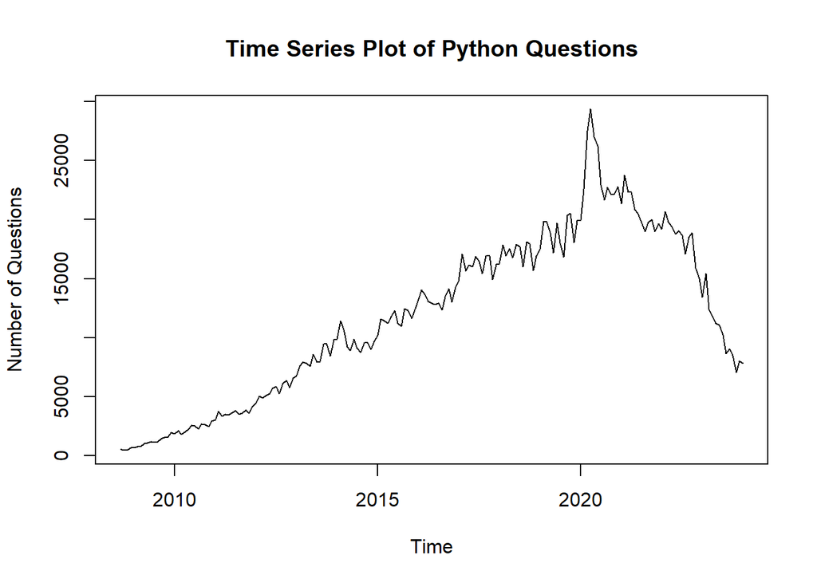

```r
# Convert 'Month' column to Date type
data$Month <- as.Date(data$Month, format = "%m/%d/%Y")

# Convert it into Time Series data
data_ts <- ts(data$Python, start = c(2008,9), frequency = 12)

# Plot the original time series data of Python Question from 2008-2022
plot(data_ts, main = "Time Series Plot of Python Questions", xlab = "Time", ylab = "Number of Questions")
```

##### Initial Observations

- First we import the dataset and print the head of data to see our data must be succesfully uploaded or not.
- In the second step we convert the month column to data type to better use the column in arima model.
- Convert the data into time series data format to forecast the data.
- We start with plotting the time series to visualise and understand the data.
- The plot shows that there is an increasing trend in the python questions starting from 2008 till around 2021.
- From 2021 till 2024, there has been observed a decreasing trend in the python questions.
- If we were to forecast the data, we should be considering the window from 2018.

## Considering only a window from 2018 to 2024

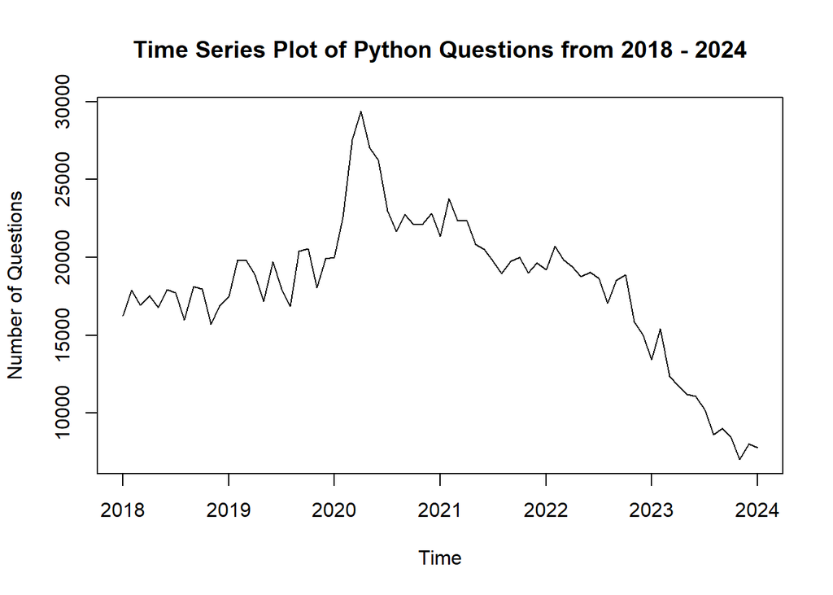

```r
data_ts_actual <- window(data_ts, start = 2018, end = 2024 )
plot(data_ts_actual, main = "Time Series Plot of Python Questions from 2018 - 2024", xlab = "Time", ylab = "Number of Questions")
```

## 1. Fit ARIMA and Explain Output

```r
# NSDIFFS only works for seasonal data
nsdiffs(data_ts_actual)
```

```
## [1] 0
```

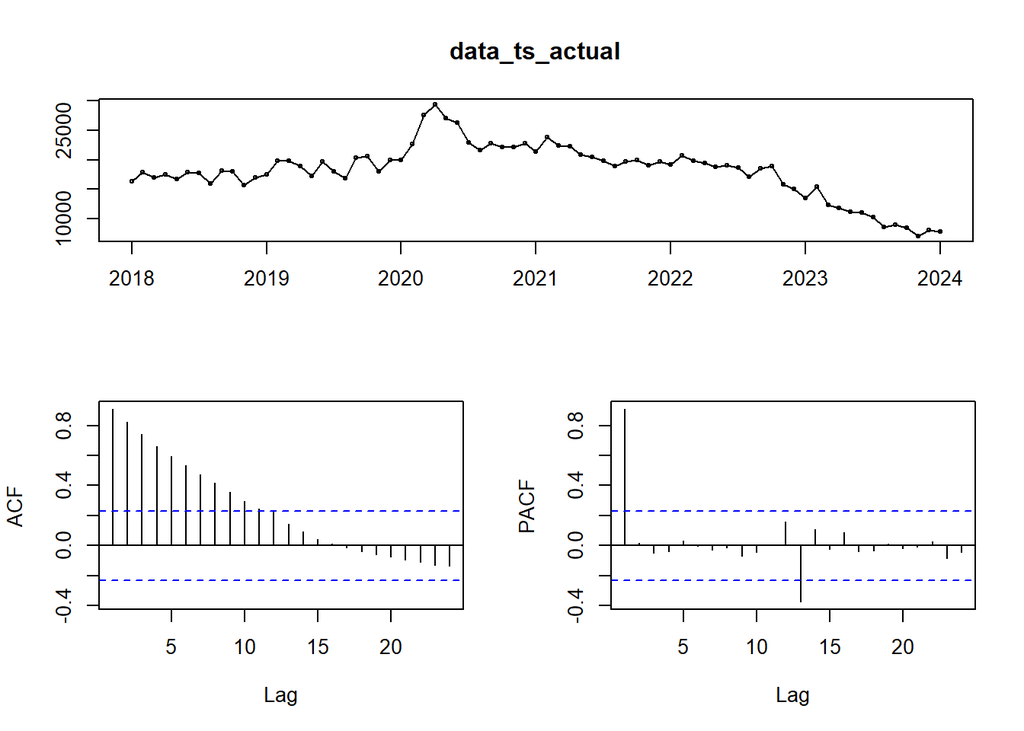

```r
#tsdisplay plots ACF,PACF and timeseries plot together
tsdisplay(data_ts_actual)
```

```r
# Fit ARIMA model
arima_model <- auto.arima(data_ts_actual)
arima_model
```

```
## Series: data_ts_actual
## ARIMA(0,1,0)(1,0,0)[12]
##
## Coefficients:
##         sar1
##       0.4714
## s.e.  0.1023
##
## sigma^2 = 1867751:  log likelihood = -623.02
## AIC=1250.03   AICc=1250.21   BIC=1254.59
```

```r
# Print the summary of the ARIMA model
summary(arima_model)
```

```
## Series: data_ts_actual
## ARIMA(0,1,0)(1,0,0)[12]
##
## Coefficients:
##         sar1
##       0.4714
## s.e.  0.1023
##
## sigma^2 = 1867751:  log likelihood = -623.02
## AIC=1250.03   AICc=1250.21   BIC=1254.59
##
## Training set error measures:
##                     ME     RMSE      MAE        MPE     MAPE      MASE
## Training set -99.76853 1347.805 1008.165 -0.8905441 5.659816 0.2431753
##                    ACF1
## Training set 0.07007458
```

## Interpretation

- nsdiffs specifies that no seasonal differencing is required for the time series.The data is already stationary in terms of seasonality, or the seasonal component is negligible.
- tsdisplay plots ACF,PACF and timeseries plot together.For more understanding the data.
- The ARIMA model fitted to the time series indicates the parameters (p, d, q) used. This suggests the autoregressive, differencing, and moving average terms for the series.
- The AIC/BIC values in the model output help evaluate how well the model fits the data, with lower values indicating better fit.
- The ARIMA(0,1,0)(1,0,0)[12] model is well-suited for the data and performs effectively in capturing both trends and seasonality.
- We can use this model for short-term forecasting with confidence.
- Low AIC (1250.03) and residual diagnostics confirm the model is well-suited for short-term forecasting.
- The model is reliable, but consider SARIMA or external regressors for further improvement if necessary.

## 3. Residual Analysis

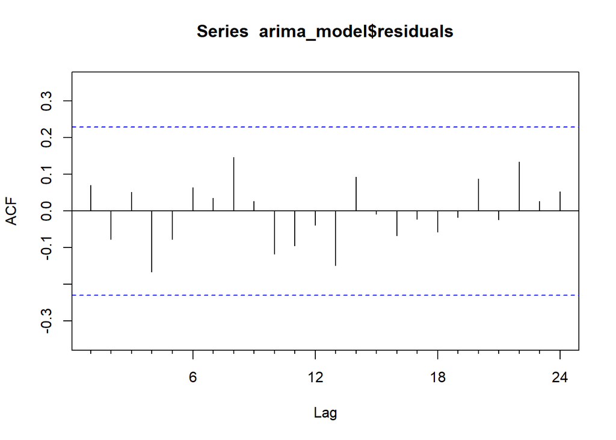

```r
# We are not finished till we do some residual analysis
#ACF plot, Box Ljung test and histogram and Timeseries plot

# Plot ACF for residuals
Acf(arima_model$residuals)
```

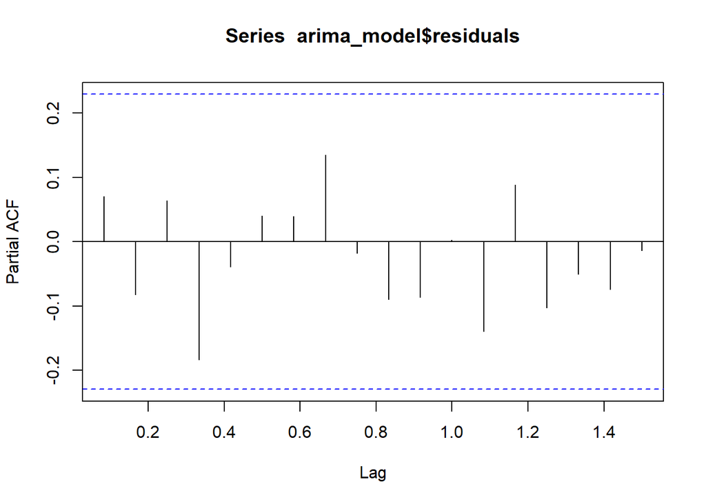

```r
# Plot PACF for residuals
pacf(arima_model$residuals)
```

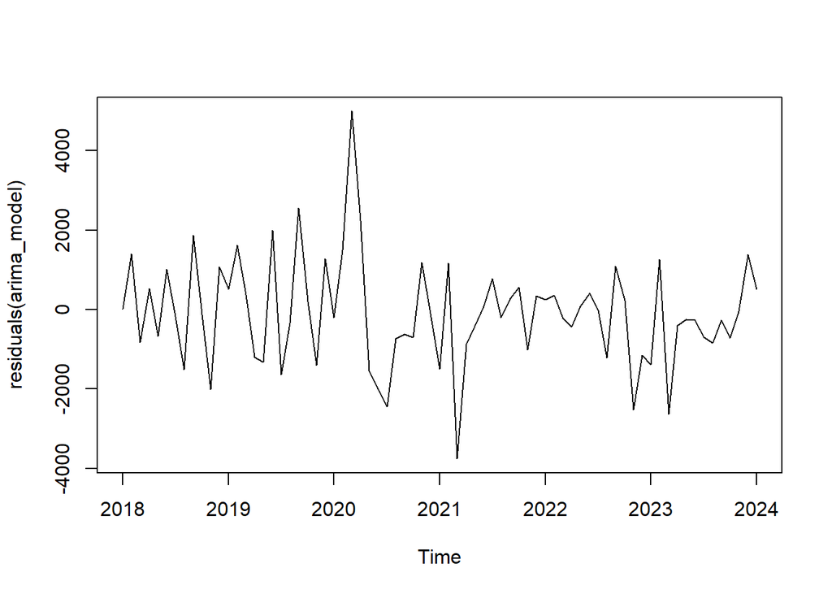

```r
#Plotting time series graph of residuals
plot.ts(residuals(arima_model))
```

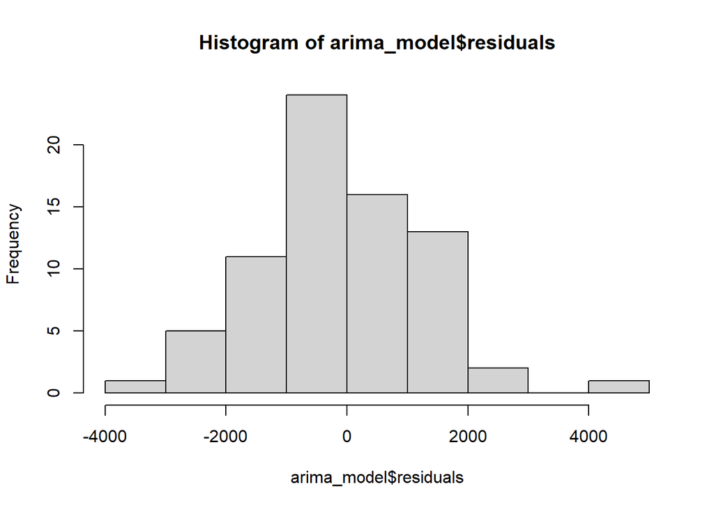

```r
#Plotting histogram graph of residuals
hist(arima_model$residuals)
```

```r
#Box Ljung test
Box.test(residuals(arima_model), lag=20, type="Ljung")
```

```
##
##  Box-Ljung test
##
## data:  residuals(arima_model)
## X-squared = 12.549, df = 20, p-value = 0.8959
```

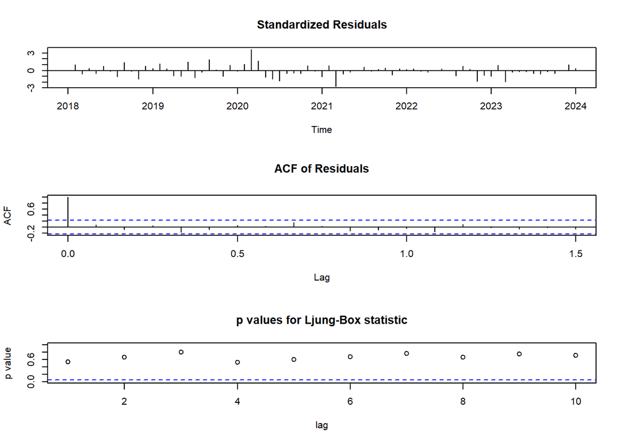

```r
# Do all the plots in one!
tsdiag(arima_model)
```